# R Notebook

# Chapter 2

## Experiment 1 (Proof of concept)

The objective of Experiment 1 was to establish baseline PSE response patterns in younger adults, and examine how PSE magnitudes differ across the three response-option conditions (RF-judgments / RFB-judgments / RF-Ratings). A 2x3 mixed factorial design was utilised, consisting of a within-subjects variable of stimulus type (words / grey-scale line-drawings) and a between-subjects variable of response-option (RF-judgments / RFBG-judgments / RF-Ratings).

## Participants

A total of 186 subjects completed the online experiment: 122 females (*M* age = 26.02 years, *SD* = 10.04), 60 males (*M* = 28.1 years, *SD* = 10.98), and 2 non-binary (*M* = 19.5 years, *SD* = 2.121). This sample size is typical in the literature for a medium effect size (.25), however, due to mixed conclusions regarding the direction of R + F, it was difficult to determine an exact a-priori number of subjects.

To meet our YA requirements, all participants were required to be between 18-59 years of age (actual range: 18-59). As our experiment involved English word stimuli, we also asked subjects whether English was their first language; the vast majority (93.01%) reported that English was indeed their first language.

The current sample was primarily comprised of participants sourced from voluntary participation websites such as (52.15%), where payment at the rate of £5/hr was given, and via the in-school (41.4%), where they received course participation credits. A small number of participants were also recruited from social media and other online sources (Facebook: 3.76%; Call For Participants: 1.61%; Reddit: 0.54%; unspecified: 0.54%).

## Materials

A random pool of grey-scale line-drawings were sourced from @rossion2004, along with their corresponding written-word object names (see Appendix XX). All items were imported into Photoshop CC (20.0.04 Release), where they were converted from their native .bmp file format into .png files. The corresponding written-word items were also created in Photoshop using the Calibri sans-serif typeface and again exported as .pngs. All items were automatically resized and presented at 250x250px by the online survey platform.

## Procedure

Data collection was conducted via the online survey platform . Participants initially completed an encoding phase, where target stimuli (word and picture stimuli) were randomly presented one-at-a-time on-screen. To ensure subjects’ directed their attention toward stimuli during the study phase, we utilised a simple encoding question at study: “Is this a picture or a word?”. All participants showed a response accuracy of +>90% at study, indicating a high rate of attention toward the presented stimuli. This ability to determine whether participants were concentrating at study is why a blocked design was avoided at study (i.e. separate word / picture blocks); separate blocks for each stimuli-format would make our current encoding question redundant, and whilst we could have used a different question (e.g. “Is this item pleasant?”), we were keen to avoid any aforementioned levels-of-processing effects, whereby deep processing questions may result in ceiling effects for responses made toward picture stimuli.

The encoding phase was followed by a short distractor task, whereby participants completed 20 multiplication sums. This was followed by the recognition task, where subjects were again randomly presented with word and picture items on-at-a-time on-screen, and were required to respond “Old”/“New” depending on whether the recognised the item or not. “Old” responses were succeeded by a follow-up screen whereby participants were asked to report their recognition experience for the current item; the response-options available during this follow-up response page differed between participants, with random allocation into either the RFG, RFBG, or RF-Ratings response-option conditions. Instructions for the memory test were highly similar between conditions, deviating only to explain key changes such as: additional response options (i.e. “Both”, in the RFBG condition), and how certain responses should be reported (i.e. 0 on both scales to represent “Guessing” in the RF-Ratings condition).

## Data analysis

Note: should we have a performance cut off? Some people have very low performance (like 0 or 1 hits) and should probably be excluded?

# Results

## Overall hits, false alarms (FAs), and recognition

Separate 2 (stimuli format: words, pictures) x 3 (response-option condition: RFG-judgments, RFBG-judgments, RF-ratings) mixed ANOVAs were conducted on the mean proportion of hits and false alarms (FAs; see Table 1).

In the ANOVA on the proportion of hits, there was a significant main effect of stimuli-format, $F(1, 183) = 131.77$, $\mathit{MSE} = 0.01$, $p < .001$; pictures ($M = 0.62$) produced a higher number of hits than words ($M = 0.47$), , supporting the notion that stimuli-format plays a role in item recognition. There was also a significant main effect of response-option condition, $F(2, 183) = 6.46$, $\mathit{MSE} = 0.09$, $p = .002$, with the RFG group ($M = 0.62$) showing more hits compared to the RF-Ratings group ($M = 0.48$), , suggesting fewer available response-options may facilitate accurate recognition. There were no significant interaction effects, $F(2, 183) = 0.35$, $\mathit{MSE} = 0.01$, $p = .707$. Click here to see output: [Appendix A - ANOVA Prop hits][].

The ANOVA on the proportion of FAs also highlights the role of stimuli-format on the memorability of items, with a significant main effect of stimuli-format $F(1, 183) = 61.18$, $\mathit{MSE} = 0.01$, $p < .001$ showing words ($M = 0.21$) produced more FAs than pictures ($M = 0.12$), . There was no significant main effect of response-option condition, $F(2, 183) = 2.70$, $\mathit{MSE} = 0.03$, $p = .070$, or significant interaction, $F(2, 183) = 0.51$, $\mathit{MSE} = 0.01$, $p = .603$. Click here to see output: [Appendix B - ANOVA Prop FAs][].

A similar pattern was again reflected in the ANOVA on overall performance accuracy; a significant main effect of stimuli-format $F(1, 183) = 409.20$, $\mathit{MSE} = 0.01$, $p < .001$ revealed that pictures ($M = 0.50$) showed an increased overall task performance accuracy compared with words ($M = 0.27$), . There was no significant main effect of response-option condition, $F(2, 183) = 2.85$, $\mathit{MSE} = 0.08$, $p = .060$, or significant interaction, $F(2, 183) = 0.33$, $\mathit{MSE} = 0.01$, $p = .720$. Click here to see output: [Appendix C - ANOVA Overall recognition][].

## Discrimination (d’) and response bias (c)

The ANOVA on d’ scores was consistent with the hits, FAs, and overall recognition findings; there was a significant main effect of stimuli-format, $F(1, 183) = 295.80$, $\mathit{MSE} = 0.18$, $p < .001$ showing pictures ($M = 1.62$) facilitated better discrimination between hits and FAs than words ($M = 0.86$), . There was again no significant main effect of response-option condition, $F(2, 183) = 1.53$, $\mathit{MSE} = 0.84$, $p = .219$, or significant interaction, $F(2, 183) = 0.25$, $\mathit{MSE} = 0.18$, $p = .778$. Click here to see output: [Appendix D - ANOVA d’ (discrimination)][].

In the ANOVA on c-scores, there was no significant main effect of stimuli-format, $F(1, 183) = 2.31$, $\mathit{MSE} = 0.11$, $p = .130$, indicating response bias was unaffected regardless of whether participants were responding to words or pictures. There was, however, a significant main effect of response-option condition, $F(2, 183) = 6.44$, $\mathit{MSE} = 0.51$, $p = .002$; those in the RF-Ratings condition ($M = 0.67$) showed higher c-scores (and thus a more conservative response bias) than those in the RFG condition ($M = 0.34$), , suggesting participants were less likely to respond “Old” when they were required to provide more detailed follow-up recognition judgments (Recollection: 0-5 / Familiarity: 0-5), compared to simply selecting one of three options (R,F, or G). There were no significant interaction effects, $F(2, 183) = 0.14$, $\mathit{MSE} = 0.11$, $p = .869$. Click here to see output: [Appendix E - ANOVA c (bias)][].

## Hits assigned Recollection, Familiarity, and Guessing

To determine the effects of stimuli-format and response-option on accurate recognition memory judgments, separate 2 (stimuli format: words, pictures) x 3 (response-option condition: RFG-judgments, RFBG-judgments, RF-ratings) mixed ANOVAs were conducted on the mean proportion of hits assigned Recollection, Familiarity, and Guessing (see Figure 1).

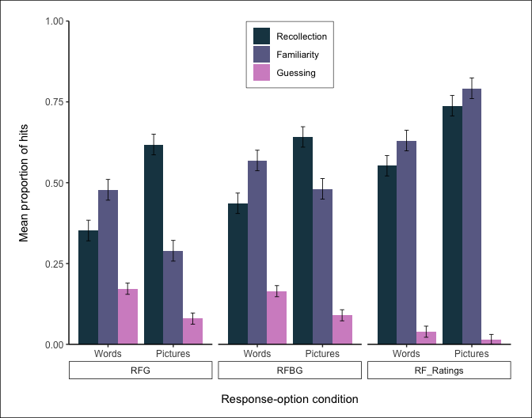

Figure 1: Proportion of hits assigned Recollection, Familiarity, and Guessing, by stimuli-format and response-option condition.

### Recollection

The ANOVA on Recollected hits revealed a significant main effect of stimuli-format, $F(1, 178) = 158.42$, $\mathit{MSE} = 0.03$, $p < .001$, with pictures ($M = 0.67$) showing a higher proportion of Recollected hits than words ($M = 0.45$), - consistent with the previous findings to suggest an enhanced memorability in pictures compared to words. There was also a significant main effect of response-option, $F(2, 178) = 8.55$, $\mathit{MSE} = 0.09$, $p < .001$; the RF-Ratings group ($M = 0.65$) showed significantly more Recollected hits compared to both the RFG-group ($M = 0.49$), , and the RFBG-group ($M = 0.54$), . There were no significant interaction effects, $F(2, 178) = 1.91$, $\mathit{MSE} = 0.03$, $p = .151$. Click here to see output: [Appendix F - ANOVA Rec hits][].

### Familiarity

In the ANOVA on Familiarity hits, there was again a significant main effect of stimuli-format, $F(1, 178) = 4.65$, $\mathit{MSE} = 0.03$, $p = .032$; words ($M = 0.56$) resulted in a higher proportion of familiarity hits than pictures ($M = 0.52$), , indicating that - when correctly recognised - words were not recognised in the the same context-rich nature as pictures. There was also a significant main effect of response-option, $F(2, 178) = 34.52$, $\mathit{MSE} = 0.09$, $p < .001$, with the RF-ratings group ($M = 0.71$) showing more Familiarity hits than both the RFG-group ($M = 0.38$), , and the RFBG-group ($M = 0.52$), . The RFBG-group ($M = 0.52$) also showed significantly more Familiarity hits compared with the RFG-group ($M = 0.38$),

There was also a significant interaction, $F(2, 178) = 34.42$, $\mathit{MSE} = 0.03$, $p < .001$ (see Figure 2). Within response-option conditions, words resulted in more Familiarity hits than pictures in both the RFG group (words: $M = 0.48$; pictures: $M = 0.29$), $t(178) = 6.07$, $p < .001$; and RFBG group (words: $M = 0.57$; pictures: $M = 0.48$), $t(178) = 2.87$, $p = .005$. Conversely, the RF-Ratings group showed the opposite pattern, with more Familiarity hits produced for pictures ($M = 0.79$) than words ($M = 0.63$), $t(178) = -5.29$, $p < .001$.

Between response-option conditions, word stimuli produced significantly more Familiarity hits in the RF-Ratings group ($M = 0.63$) compared tothe RFG group ($M = 0.48$), $t(276.78) = -3.37$, $p = .002$. For pictures, a higher number of Familiarity hits was evident in the RF-Ratings group ($M = 0.79$) compared to both the RFG group ($M = 0.29$), $t(276.78) = -11.13$, $p < .001$ and RFBG group ($M = 0.48$), $t(276.78) = -6.94$, $p < .001$. The RFBG group ($M = 0.48$) also showed a significantly higher number of Familiarity hits compared to the RFG group ($M = 0.29$), $t(276.78) = -4.24$, $p < .001$. Click here to see output: [Appendix G - ANOVA Fam hits][].

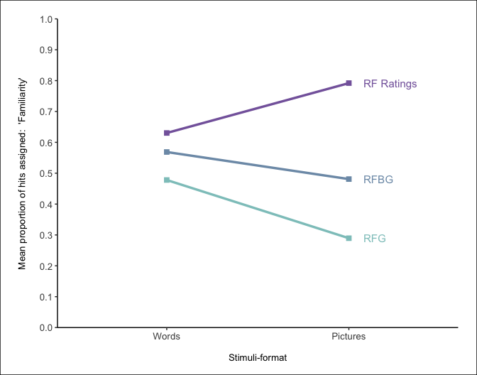

Figure 2: Interaction plot between stimuli-format and response-option condition for the mean proportion of hits assigned ‘Familiarity’.

### Guessing

The ANOVA on Guessing hits again showed a significant main effect of stimuli-format, $F(1, 178) = 42.84$, $\mathit{MSE} = 0.01$, $p < .001$, with words ($M = 0.13$) showing more Guessing hits than pictures ($M = 0.06$), - a finding that aligns with the results for hits assigned Recollection and Familiarity, whereby words appear to not be recognised in the the same context-rich nature as pictures. There was also a significant main effect of response-option, $F(2, 178) = 14.97$, $\mathit{MSE} = 0.03$, $p < .001$, with the RF-Ratings group ($M = 0.03$) showing significantly fewer Guessing hits than both the RFG ($M = 0.13$), , and RFBG ($M = 0.13$) groups, . Despite ‘Guessing’ responses being permissable in any of the response-option groups, it seems when two independent rating scales were required participants were less likely to report a “Guess”. This could be because those in the RF-Ratings condition selected “New” more often than “Old” when they were having a complete guess, or instead, subjects might have opted to report lower levels of Recollection and Familiarity ratings (i.e., 1-3), rather than responding 0 on both scales.

There was also a significant interaction,$F(2, 178) = 4.17$, $\mathit{MSE} = 0.01$, $p = .017$, (see Figure 3). Within response-option conditions, words resulted in more Guessing hits than pictures in both the RFG group (words: $M = 0.17$; pictures: $M = 0.08$), $t(178) = 5.38$, $p < .001$; and RFBG group (words: $M = 0.16$; pictures: $M = 0.09$), $t(178) = 4.42$, $p < .001$.

Between response-option conditions, word stimuli produced significantly fewer Guessing hits in the RF-Ratings group ($M = 0.04$) compared to both the RFG group ($M = 0.17$), $t(281.42) = 5.44$, $p < .001$, and the RFBG group ($M = 0.16$), $t(281.42) = 5.18$, $p < .001$. A similar pattern was also evident for pictures, with significantlyfewer of Guessing hits in the RF-Ratings group ($M = 0.01$) compared to both the RFG group ($M = 0.08$), $t(281.42) = 2.70$, $p = .020$ and RFBG group ($M = 0.09$), $t(281.42) = 3.15$, $p = .005$. Click here to see output: [Appendix H - ANOVA guess hits][].

[output not shown]

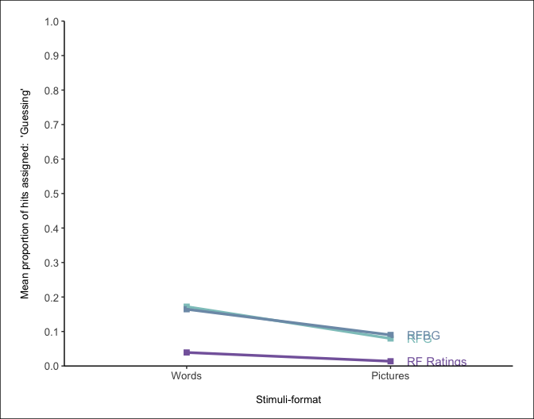

Figure 3: Interaction plot between stimuli-format and response-option condition for the mean proportion of hits assigned ‘Guessing’.

## False alarms (FAs) assigned Recollection, Familiarity, and Guessing

To determine the effects of stimuli-format and response-option on false recognition memory judgments, separate 2 (stimuli format: words, pictures) x 3 (response-option condition: RFG-judgments, RFBG-judgments, RF-ratings) mixed ANOVAs were conducted on the mean proportion of FAs assigned Recollection, Familiarity, and Guessing (see Figure 4).

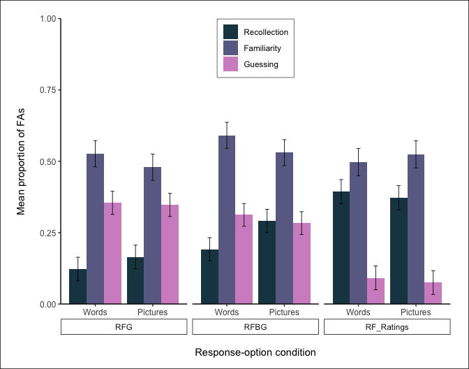

Figure 4: Proportion of FAs assigned Recollection, Familiarity, and Guessing, by stimuli-format and response-option condition.

### Recollection (FAs)

In the ANOVA on Recollection FAs, there was no significant main effect of stimuli-format, $F(1, 136) = 2.78$, $\mathit{MSE} = 0.04$, $p = .098$, but there was a significant main effect of response-option, $F(2, 136) = 10.70$, $\mathit{MSE} = 0.12$, $p < .001$, with those in the RF-ratings group ($M = 0.38$) showing more Recollection FAs than both the RFG-group ($M = 0.14$), , and the RFBG-group ($M = 0.24$), ).

This could indicate that when subjects were required to individually report Recollection and Familiarity on two 0-5 rating scales, they were more likely to experience (or report) false recognition (accompanied by non-existent contextual details) than when only three (RFG) or four (RFBG) response-options were provided. There were no significant interaction effects, $F(2, 136) = 2.08$, $\mathit{MSE} = 0.04$, $p = .129$. Click here to see output: [Appendix I - ANOVA Rec FA][].

### Familiarity (FAs)

The ANOVA on Familiarity FAs did not yield any significant results; with no significant main effect of stimuli-format, $F(1, 136) = 1.12$, $\mathit{MSE} = 0.04$, $p = .292$, no significant main effect of response-option, $F(2, 136) = 0.62$, $\mathit{MSE} = 0.15$, $p = .539$, and no significant interaction effects, $F(2, 136) = 1.12$, $\mathit{MSE} = 0.04$, $p = .331$. Click here to see output: [Appendix J - ANOVA Fam FA][].

### Guessing (FAs)

Finally, the ANOVA on Guessing FAs also showed no significant main effect of stimuli-format, $F(1, 136) = 0.51$, $\mathit{MSE} = 0.04$, $p = .476$, but there was a significant main effect of response-option, $F(2, 136) = 15.69$, $\mathit{MSE} = 0.11$, $p < .001$, with the with the RF-ratings group ($M = 0.08$) showing significantly fewer Guessing FAs than both the RFG ($M = 0.35$), , and RFBG groups ($M = 0.30$), . This again aligns with previous results, suggesting that those in the RF-Ratings group were less likely to report guesses than the other groups, whether accurate or not. There were no significant interaction effects, $F(2, 136) = 0.07$, $\mathit{MSE} = 0.04$, $p = .935$. Click here to see output: [Appendix K - ANOVA Guess FA][].